Aller au contenu principal

# Mon stage d’observation de 3ème

CentraleSupélec — Rennes

Auteur·rice

Olivier CASTAN, 3ème 3, collège JP Vernant

Date de publication

5 décembre 2026

**NoteMon stage en bref**

**Stagiaire :** Olivier Castan, élève de 3ème au collège JP Vernant  
**Lieu du stage :** CentraleSupélec, Rennes  
**Dates :** du lundi 23/11 au vendredi 27/11/2026  
**Tuteur :** Simon Leglaive, Enseignant chercheur

# 1 Introduction

## 1.1 Ma recherche de stage

J’ai connu cette institution par relation familiale. Pour l’obtention du stage, je suis passé par l’envoi d’un mail de demande de stage.  
J’attendais de ce stage de découvrir la vie dans les écoles d’ingénieurs, et découvrir le métier d’enseignant-chercheur.

# 2 Le lieu de stage

## 2.1 Présentation générale

- **Nom :** CentraleSupélec
- **Adresse :** 1 avenue de la Boulaie, Cesson-Sévigné
- **Domaine d’activité :** Enseignement supérieur et recherche

[figure not shown]

Figure 1: Photo du bâtiment

## 2.2 Les métiers et l’organisation

### 2.2.1 Les employés et les horaires de travail

Nombre d’employés sur le campus : 80  
Femmes : 22  
Hommes : 58

**AstuceHoraires de travail et congés**

Un enseigant-chercheur doit travailler environ 1600 heures par an, dont :  
- 800 heures de recherche ;  
- 800 heures d’enseignement, dont 25% (200 heures) face aux élèves.  
Ils font entre 35 et 40 heures par semaine et il leur reste donc 5 à 8 semaines de congés.

### 2.2.2 Les métiers

#### Organigrammes

[figure not shown]

Figure 2: Organigramme du Campus

[figure not shown]

Figure 3: Organigramme de l’administration

[figure not shown]

Figure 4: Organigramme du laboratoire

#### Les métiers et leurs activités

Tableau 1: Les métiers et leurs activités

| Métier | Activités |
| --- | --- |
| Enseignant-chercheur | Produire des connaissances et les transmettre |
| Post-doctorant | Produire et diffuser des connaissances |
| Assisstant de direction | Administrer |
| Assisstant de scolarité | Administrer |

# 3 Mon journal de bord

## 3.1 Lundi 23/11

**Ce que j’ai fait :** Visite de l’amphithéâtre (voir Figure 5), j’ai aussi assisté à des réunions recherche.

**Ce que j’ai appris :** Renaud S. m’a présenté les start up qu’il a cofondées.

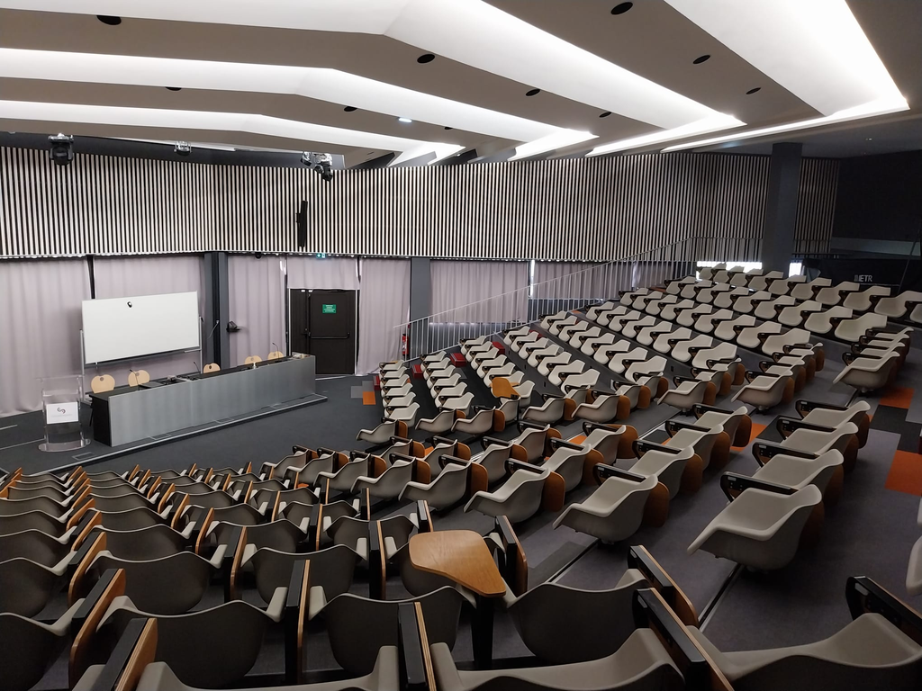

Figure 5: L’amphithéâtre du campus

## 3.2 Mardi 24/11

**Ce que j’ai fait :** Aide à la mise en place d’un atelier pour les étudiants internationaux, échange avec Tiphaine à propos d’une start up

**Ce que j’ai appris :** Découverte du BrevetAI, un site de formation à l’intelligence artificielle

**ImportantCe qui m’a surpris**

J’ai appris que dans les élèves de tous les campus de CentralSupélec, plus de 70 nationalités différentes sont représentées.

## 3.3 Mercredi 25/11

**Ce que j’ai appris :** J’ai suivi une formation sur les impacts environnementaux directs et indirects de l’Intelligence artificielle, et j’ai assisté à un cours de Simon L. sur le machine learning

**NoteImpacts environnementaux directs et indirects de l’IA**

- Les impacts environnementaux directs de l’intelligence artificielle sont les impacts liés au cycle de vie des équipements numériques, notamment lors de leur extraction et de leur distribution, mais aussi lors de leur utilisation, comme la haute consommation en eau des serveurs.
- Les impacts environnementaux indirects de l’intelligence artificielle sont les impacts que l’IA a sur d’autres secteurs, sur les écosystèmes ou sur les comportements humains; ces impacts ne sont pas causés directement par cette activité mais en résultent de manière indirecte. Par exemple, si on intègre une IA dans une voiture afin qu’elle optimise les trajets pour qu’ils limitent la consommation de la voiture, cela peut amener les utilisateurs à utiliser plus souvent leur voiture car ils auront moins d’essence à payer, et donc obtenir l’effet inverse. Cependant, si les utilisateurs n’utilisent pas plus leur voiture malgré ce progrès, alors l’impact indirect sera positif pour l’environnement.

# 4 Les métiers que j’ai découverts

## 4.1 Chercheur Post-doctorant

**Personne interrogée :** Louis B., chercheur post-doctorant

**Concrètement, en quoi consiste votre métier ?** Produire de la connaissance : développer des modèles, les valider à l’aide d’expériences; et transmettre cette connaissance en écrivant des articles et des revues.

**Quelles qualités doit-on développer pour exercer ce métier ?** Beaucoup de curiosité : il faut aimer apprendre, et chercher à comprendre.

**Combien d’heures par semaine travaillez vous en moyenne ?** Environ 40 heures par semaine.

**Quel est votre parcours scolaire initial(niveau d’arrêt des études au départ)?** Après le bac, j’ai fait une classe préparatoire, puis une école d’ingénieur (IMT Nord Europe), et enfin une thèse à Télécom Paris.

**Avez vous du rependre un parcours de formation par la suite ?** Mon travail en lui-même est une formation pérpétuelle : dans la racherche, on n’a jamais fini d’apprendre.

**A quels postes avez vous déjà travaillé en dehors de celui ci ?** J’ai été doctorant à Télécom Paris, de 2022 à 2025.

**Avec quels autres professionnels ou services êtes vous en relation ?** je suis en relation avec les services d’appui à le recherche : ils aident à l’organisation des voyages pour les conférences, etc. Je suis aussi en relation avec des chercheurs dans d’autres entreprises ou universités.

> « Dans la recherche, on n’a jamais fini d’apprendre; et c’est d’ailleurs ce qui nous anime : apprendre et comprendre. »

# 5 Bilan

## 5.1 Ce que j’ai appris

J’ai appris qu’il avait des chercheurs partout sur terre, et que la recherche est toute une communauté. De plus, les études sont les mêmes (tout le monde fait une thèse). Je me suis aussi rendu compte que même si le rythme de travail est plus intense qu’au collège, je suis moins fatigué à la fin, car j’aime ce que je fais.

## 5.2 Les avantages et inconvénients des métiers que j’ai découverts, et les qualités nécessaires pour les exercer

Pour exercer ces métiers, il faut beaucoup travailler (1600h/an et 35-40h/semaine); il faut aussi faire de longues études (doctorat), mais on est assez bien à très bien payé, et on est très libre dans nos recherches, personne ne nous dit quoi faire.

**ImportantQualités/compétences nécessaires pour être chercheur**

1. Qualités
- Autonomie
- Persévérance
- Curiosité
- Ethique et intégrité (respect des droits d’auteur, etc)
2. Compétences méthodologiques
- Analyse de l’information (lire, comprendre des documents complexes)
- Esprit critique (ex : évaluer la qualité d’une source)
- Résoudre des problèmes complexes
- Méthode sientifique (poser une hypothèse, etc)
- Rigueur
- Gestion de projet
3. Compétences en communication
- Rédaction scientifique (structurer des rapports, des articles)
- Présentation orale (vulgariser ou défendre un travail face à différents publics)
- Travail collaboratif (co-écriture, etc)

## 5.3 Ce qui m’a plu, ce qui m’a moins plu

- J’ai aimé : J’avais beaucoup de libertés lors de ce stage : je pouvais choisir où je voulais aller, ce que je voulais faire. J’ai aussi aimé discuter avec des personnes exerant différents métiers, et la convivialité.
- J’ai moins aimé : Lorsqu’il m’arrivait de ne pas comprendre le contenu des réunions